# Prosper loans project

### by Michał Kaszuba

This project was created during Data Analyst Nanodegree by Udacity [Visit Udacity](https://www.udacity.com) Data set was downloaded form Udacity site

This data set contains 113,937 loans with 81 variables on each loan, including loan amount, borrower rate (or interest rate), current loan status, borrower income, and many others.

I will try to anwser following questions:

Are people who own property are more willing to take loans?

Is specific occupations are more willing to take loans, and which one has the highest debts (Income to debt ratio)?

What affects the borrower’s APR or interest rate?

```python
import pandas as pd
import numpy as np
import seaborn as sb
import matplotlib.pyplot as plt
%matplotlib inline
```

```python
loan = pd.read_csv('./prosperLoanData.csv')
```

First look at the data set

```python
loan.info()
```

```
<class 'pandas.core.frame.DataFrame'>
RangeIndex: 113937 entries, 0 to 113936
Data columns (total 81 columns):
 #   Column                               Non-Null Count   Dtype
---  ------                               --------------   -----
 0   ListingKey                           113937 non-null  object
 1   ListingNumber                        113937 non-null  int64
 2   ListingCreationDate                  113937 non-null  object
 3   CreditGrade                          28953 non-null   object
 4   Term                                 113937 non-null  int64
 5   LoanStatus                           113937 non-null  object
 6   ClosedDate                           55089 non-null   object
 7   BorrowerAPR                          113912 non-null  float64
 8   BorrowerRate                         113937 non-null  float64
 9   LenderYield                          113937 non-null  float64
```

[output cut: 73 more lines]

```python
loan.head(3)
```

|  | ListingKey | ListingNumber | ListingCreationDate | CreditGrade | Term | LoanStatus | ClosedDate | BorrowerAPR | BorrowerRate | LenderYield | ... | LP_ServiceFees | LP_CollectionFees | LP_GrossPrincipalLoss | LP_NetPrincipalLoss | LP_NonPrincipalRecoverypayments | PercentFunded | Recommendations | InvestmentFromFriendsCount | InvestmentFromFriendsAmount | Investors |
| --- | --- | --- | --- | --- | --- | --- | --- | --- | --- | --- | --- | --- | --- | --- | --- | --- | --- | --- | --- | --- | --- |
| 0 | 1021339766868145413AB3B | 193129 | 2007-08-26 19:09:29.263000000 | C | 36 | Completed | 2009-08-14 00:00:00 | 0.16516 | 0.158 | 0.138 | ... | -133.18 | 0.0 | 0.0 | 0.0 | 0.0 | 1.0 | 0 | 0 | 0.0 | 258 |
| 1 | 10273602499503308B223C1 | 1209647 | 2014-02-27 08:28:07.900000000 | NaN | 36 | Current | NaN | 0.12016 | 0.092 | 0.082 | ... | 0.00 | 0.0 | 0.0 | 0.0 | 0.0 | 1.0 | 0 | 0 | 0.0 | 1 |
| 2 | 0EE9337825851032864889A | 81716 | 2007-01-05 15:00:47.090000000 | HR | 36 | Completed | 2009-12-17 00:00:00 | 0.28269 | 0.275 | 0.240 | ... | -24.20 | 0.0 | 0.0 | 0.0 | 0.0 | 1.0 | 0 | 0 | 0.0 | 41 |

3 rows × 81 columns

We will be only intrested in few columns for further analysis:

ListingKey : Unique key for each listing, same value as the 'key' used in the listing object in the API.

Term : The length of the loan expressed in months.

BorrowerAPR : The Borrower's Annual Percentage Rate (APR) for the loan.

BorrowerRate : The Borrower's interest rate for this loan.

ProsperScore : A custom risk score built using historical Prosper data. The score ranges from 1-10, with 10 being the best, or lowest risk score. Applicable for loans originated after July 2009

Occupation: The Occupation selected by the Borrower at the time they created the listing.

IsBorrowerHomeowner : A Borrower will be classified as a homowner if they have a mortgage on their credit profile or provide documentation confirming they are a homeowner.

DebtToIncomeRatio: The debt to income ratio of the borrower at the time the credit profile was pulled. This value is Null if the debt to income ratio is not available. This value is capped at 10.01 (any debt to income ratio larger than 1000% will be returned as 1001%).

Now when We know what We want. Let's create dataset this way

```python
loans = pd.read_csv('./prosperLoanData.csv', usecols=['ListingKey','Term','BorrowerAPR','BorrowerRate','ProsperScore',
                                                     'Occupation','IsBorrowerHomeowner','DebtToIncomeRatio'])
```

```python
loans.tail(2)
```

|  | ListingKey | Term | BorrowerAPR | BorrowerRate | ProsperScore | Occupation | IsBorrowerHomeowner | DebtToIncomeRatio |
| --- | --- | --- | --- | --- | --- | --- | --- | --- |
| 113935 | E6EB3531504622671970D9E | 60 | 0.28408 | 0.2605 | 5.0 | Food Service | True | 0.48 |
| 113936 | E6ED3600409833199F711B7 | 36 | 0.13189 | 0.1039 | 7.0 | Professor | False | 0.23 |

```python
loans.info()
```

```
<class 'pandas.core.frame.DataFrame'>
RangeIndex: 113937 entries, 0 to 113936
Data columns (total 8 columns):
 #   Column               Non-Null Count   Dtype
---  ------               --------------   -----
 0   ListingKey           113937 non-null  object
 1   Term                 113937 non-null  int64
 2   BorrowerAPR          113912 non-null  float64
 3   BorrowerRate         113937 non-null  float64
 4   ProsperScore         84853 non-null   float64
 5   Occupation           110349 non-null  object
 6   IsBorrowerHomeowner  113937 non-null  bool
 7   DebtToIncomeRatio    105383 non-null  float64
dtypes: bool(1), float64(4), int64(1), object(2)
memory usage: 6.2+ MB
```

Ok. Data looks fine in general. We got some missing values in columns DebtToIncomeRatio, ProsperScore and some in Occupation. However, I won't be discarding them as yet. For now, let's just check if all values in columns are fine.

```python
loans['ListingKey'].is_unique
```

```
False
```

Hmm interesting. According to descriptions that should be true. Let's investigate that further.

```python
uniqueloanslist = loans['ListingKey'].drop_duplicates().index.to_list()
```

```python
notuniquekeys = []
for _ in range(len(loans)):
    if _ in uniqueloanslist:
        continue
    else:
        notuniquekeys.append(_)
```

```python
loans.drop(axis=0,index=notuniquekeys,inplace=True)
```

```python
loans['ListingKey'].is_unique
```

```
True
```

Now We will be working only with unique keys.

Let's move to the next column

```python
loans['Term'].value_counts()
```

```
36    87224
60    24228
12     1614
Name: Term, dtype: int64
```

So, We got 3 types of loans in the dataset in terms of the length of the loan expressed in months.

Looks fine. Nothing to do here. Next one:

```python
loans.where(loans['BorrowerAPR'] <0).dropna()
```

|  | ListingKey | Term | BorrowerAPR | BorrowerRate | ProsperScore | Occupation | IsBorrowerHomeowner | DebtToIncomeRatio |
| --- | --- | --- | --- | --- | --- | --- | --- | --- |

```python
loans.where(loans['BorrowerAPR'] >0.5).dropna()
```

|  | ListingKey | Term | BorrowerAPR | BorrowerRate | ProsperScore | Occupation | IsBorrowerHomeowner | DebtToIncomeRatio |
| --- | --- | --- | --- | --- | --- | --- | --- | --- |

All the loans ARP's are between 0% and 50%. And they are all float point numbers, so that's good.

Next one:

```python
loans.where(loans['BorrowerRate'] <0).dropna()
```

|  | ListingKey | Term | BorrowerAPR | BorrowerRate | ProsperScore | Occupation | IsBorrowerHomeowner | DebtToIncomeRatio |
| --- | --- | --- | --- | --- | --- | --- | --- | --- |

```python
loans.where(loans['BorrowerRate'] >0.5).dropna()
```

|  | ListingKey | Term | BorrowerAPR | BorrowerRate | ProsperScore | Occupation | IsBorrowerHomeowner | DebtToIncomeRatio |
| --- | --- | --- | --- | --- | --- | --- | --- | --- |

Same for Borrower Rates so, that's good too.

Prosper Score should be between 1 and 10. Let's check:

```python
loans.where(loans['ProsperScore'] <1).dropna()
```

|  | ListingKey | Term | BorrowerAPR | BorrowerRate | ProsperScore | Occupation | IsBorrowerHomeowner | DebtToIncomeRatio |
| --- | --- | --- | --- | --- | --- | --- | --- | --- |

```python
loans.where(loans['ProsperScore'] >10).dropna()
```

|  | ListingKey | Term | BorrowerAPR | BorrowerRate | ProsperScore | Occupation | IsBorrowerHomeowner | DebtToIncomeRatio |
| --- | --- | --- | --- | --- | --- | --- | --- | --- |
| 158 | 108E36027739898797E47EC | 36.0 | 0.09469 | 0.0809 | 11.0 | Tradesman - Mechanic | False | 0.05 |
| 224 | 2F293599751524472C82DEA | 36.0 | 0.13799 | 0.1099 | 11.0 | Sales - Commission | True | 0.11 |
| 236 | 11D335932344051959C94C6 | 36.0 | 0.06726 | 0.0605 | 11.0 | Tradesman - Mechanic | True | 0.14 |
| 277 | 2EFC36028887817232507BC | 60.0 | 0.15868 | 0.1355 | 11.0 | Other | False | 0.19 |
| 476 | 00EC3604528464581EB9190 | 60.0 | 0.14528 | 0.1224 | 11.0 | Other | False | 0.29 |
| ... | ... | ... | ... | ... | ... | ... | ... | ... |
| 113762 | E41735941348970874153D6 | 60.0 | 0.13636 | 0.1139 | 11.0 | Other | True | 0.23 |
| 113784 | CF4C3593704223935C8DEF5 | 36.0 | 0.12691 | 0.0990 | 11.0 | Other | True | 0.30 |
| 113855 | DF45360176809914475660A | 36.0 | 0.14751 | 0.1189 | 11.0 | Food Service Management | False | 0.07 |
| 113881 | E2C73590325077098CCF6F5 | 60.0 | 0.19681 | 0.1730 | 11.0 | Professional | True | 0.29 |
| 113912 | C98A3597264633447D66DF9 | 36.0 | 0.06726 | 0.0605 | 11.0 | Scientist | False | 0.20 |

1367 rows × 8 columns

We got 1367 invalid records. Since We can't know for sure what would be a valid score We need to remove them.

```python
invalidscores = loans.where(loans['ProsperScore'] >10).dropna().index.to_list()
```

```python
loans.drop(axis=0,index=invalidscores,inplace=True)
```

```python
loans.where(loans['ProsperScore'] >10).dropna()
```

|  | ListingKey | Term | BorrowerAPR | BorrowerRate | ProsperScore | Occupation | IsBorrowerHomeowner | DebtToIncomeRatio |
| --- | --- | --- | --- | --- | --- | --- | --- | --- |

Ok. It is fine now.

Let's move to the next one!

```python
loans['Occupation'].value_counts()
```

```
Other                          28151
Professional                   13322
Computer Programmer             4333
Executive                       4154
Teacher                         3687
                               ...
Dentist                           65
Student - College Freshman        41
Student - Community College       28
Judge                             21
Student - Technical School        16
Name: Occupation, Length: 67, dtype: int64
```

Since in that columns we got only text. We can't be sure if values are alright or not as yet. What We can do is to categorize them for better performance of our code.

```python
loans['Occupation'] = loans['Occupation'].astype('category')
```

```python
loans = loans.astype({'ProsperScore':'int32'})
```

```python
loans.info()
```

[output not shown]

We know for sure that the next column is alright, since it's bool, and We got no missing values.

And that is exactly what We would expect, since You can either own property or not.

The last column should be capped by description to 1001% it also can't be less than 0% let's check it.

```python
loans.where(loans['DebtToIncomeRatio'] <0).dropna()
```

|  | ListingKey | Term | BorrowerAPR | BorrowerRate | ProsperScore | Occupation | IsBorrowerHomeowner | DebtToIncomeRatio |
| --- | --- | --- | --- | --- | --- | --- | --- | --- |

```python
loans.where(loans['DebtToIncomeRatio'] >10.01).dropna()
```

|  | ListingKey | Term | BorrowerAPR | BorrowerRate | ProsperScore | Occupation | IsBorrowerHomeowner | DebtToIncomeRatio |
| --- | --- | --- | --- | --- | --- | --- | --- | --- |

It's fine. Now let's remove loans where our data is not complete.

```python
loans.dropna(inplace=True)
```

```python
loans.info()
```

```
<class 'pandas.core.frame.DataFrame'>
Int64Index: 74127 entries, 1 to 113936
Data columns (total 8 columns):
 #   Column               Non-Null Count  Dtype
---  ------               --------------  -----
 0   ListingKey           74127 non-null  object
 1   Term                 74127 non-null  int64
 2   BorrowerAPR          74127 non-null  float64
 3   BorrowerRate         74127 non-null  float64
 4   ProsperScore         74127 non-null  float64
 5   Occupation           74127 non-null  category
 6   IsBorrowerHomeowner  74127 non-null  bool
 7   DebtToIncomeRatio    74127 non-null  float64
dtypes: bool(1), category(1), float64(4), int64(1), object(1)
memory usage: 4.1+ MB
```

Let's reset indexes and We will save masterdata to csv file

```python
loans.reset_index(inplace=True)
```

```python
loans.drop(axis=1,columns='index',inplace=True)
```

```python
loans.info()
```

```
<class 'pandas.core.frame.DataFrame'>
RangeIndex: 74127 entries, 0 to 74126
Data columns (total 8 columns):
 #   Column               Non-Null Count  Dtype
---  ------               --------------  -----
 0   ListingKey           74127 non-null  object
 1   Term                 74127 non-null  int64
 2   BorrowerAPR          74127 non-null  float64
 3   BorrowerRate         74127 non-null  float64
 4   ProsperScore         74127 non-null  float64
 5   Occupation           74127 non-null  category
 6   IsBorrowerHomeowner  74127 non-null  bool
 7   DebtToIncomeRatio    74127 non-null  float64
dtypes: bool(1), category(1), float64(4), int64(1), object(1)
memory usage: 3.5+ MB
```

```python
loans.to_csv('./loans.csv',index=False)
```

```python
loans = pd.read_csv('./loans.csv')
```

Our dataset is ready for investigating.

Let's start investigating first question:

Are people who own property are more willing to take loans?

# Univariate Exploration

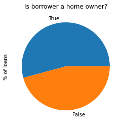

```python
loans['IsBorrowerHomeowner'].value_counts().plot(kind='pie',title='Is borrower a home owner?',ylabel='% of loans');
```

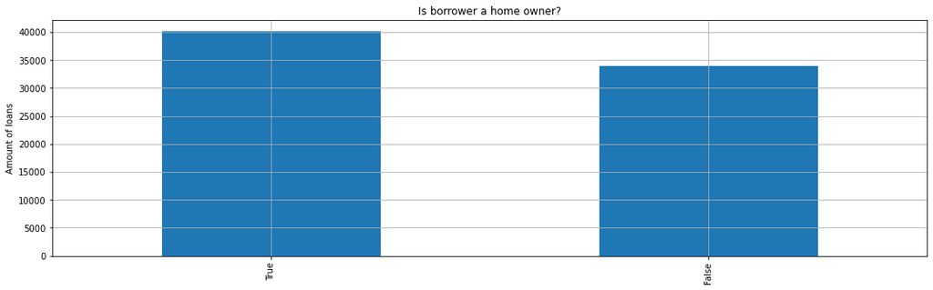

```python
loans['IsBorrowerHomeowner'].value_counts().plot(kind='bar',title='Is borrower a home owner?',
                                                 ylabel='Amount of loans',grid=True,figsize=(18,5));
```

Yes. Most of borrowers got a property. Diffrence is not huge less then 10%.

Let's check the most popular occupations among borrowers.

```python
top10occupation = loans.groupby('Occupation').size().sort_values(ascending=False).head(11)
```

```python
top10occupations = pd.DataFrame(top10occupation)
```

```python
top10occupations = top10occupations[1:]
```

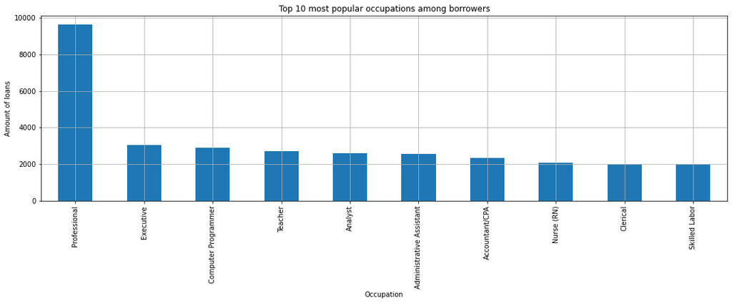

```python
top10occupations.plot(kind='bar',figsize=(18,5),title='Top 10 most popular occupations among borrowers',
                     legend=False,ylabel='Amount of loans',grid=True);
```

Professionals are by far the most popular occupation among borrower with almost triple of occurs of the second one on list Executive. We got similar levels of loans among places 2 and 10.

```python
loans.groupby('Occupation').size().where(loans.groupby('Occupation').size() <740).dropna()
```

```
Occupation
Architect                             128.0
Attorney                              671.0
Biologist                              91.0
Bus Driver                            237.0
Car Dealer                            118.0
Chemist                               106.0
Clergy                                139.0
Dentist                                43.0
Doctor                                314.0
Engineer - Chemical                   166.0
Fireman                               309.0
Flight Attendant                       85.0
Food Service                          709.0
Homemaker                              21.0
Investor                               60.0
Judge                                  21.0
Landscaping                            81.0
Military Officer                      235.0
Nurse (LPN)                           399.0
Nurse's Aide                          347.0
Pharmacist                            209.0
Pilot - Private/Commercial            139.0
Postal Service                        470.0
Principal                             240.0
Professor                             424.0
Psychologist                           87.0
Realtor                                78.0
Religious                              71.0
Scientist                             273.0
Social Worker                         539.0
Student - College Freshman             12.0
Student - College Graduate Student     73.0
Student - College Junior               18.0
Student - College Senior               35.0
Student - College Sophomore             9.0
Student - Community College             5.0
Student - Technical School              1.0
Teacher's Aide                        186.0
Tradesman - Carpenter                  47.0
Tradesman - Electrician               362.0
Tradesman - Mechanic                  725.0
Tradesman - Plumber                    66.0
Waiter/Waitress                       257.0
dtype: float64
```

The list above is a list of Occupations that occurred in less than 1% of loans. Listed Banks should consider grouping them since for example Architect could be in a group of Professionals.

How many loans were granted for each Prosper score?

```python
prosperscorecount = loans['ProsperScore'].value_counts()
prosperscorecount.sort_index(inplace=True)
```

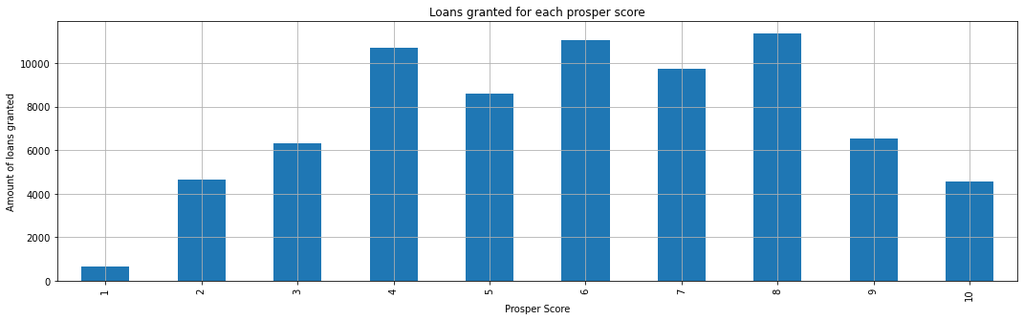

```python
prosperscorecount.plot(kind='bar',figsize=(18,5),title='Loans granted for each prosper score',
                     legend=False,ylabel='Amount of loans granted',xlabel='Prosper Score',grid=True);
```

The most common Prosper Score is 8. Very low amount of loans were granted to people with Prosper Score of 1 - less than a 1000 in whole dataset. Most of the borrowers has a Prosper score between 4-8.

We might check density of Borrowers ARP to have better understating of the outliers.

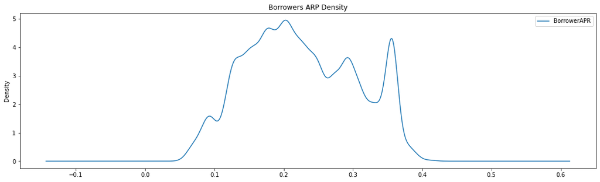

```python
loans.plot(kind='density',y='BorrowerAPR',figsize=(18,5),title="Borrowers ARP Density");
```

All the loans ARPs are in range of 5% and 40%.

And same for Debt To Income Ratio.

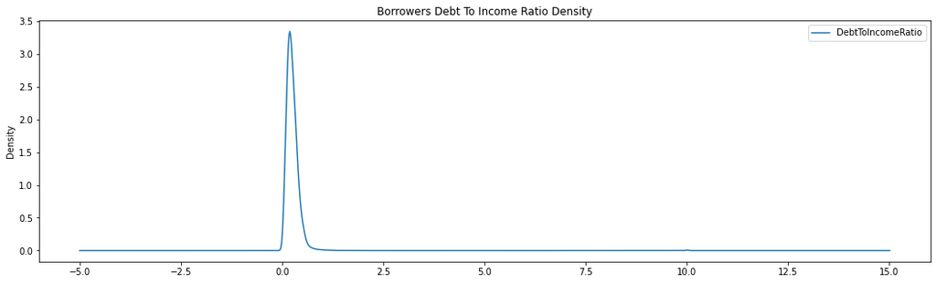

```python
loans.plot(kind='density',y='DebtToIncomeRatio',figsize=(18,5),title="Borrowers Debt To Income Ratio Density");
```

Most of the Debt To Income Ratio is between 0 and 1.5 it may help us for plotting that value latter.

# Bivariate Exploration

```python
occupationsmean = loans.groupby('Occupation').mean()
```

```python
def plotThisbar(data,title,ylabel,color):
    '''To save time we will use this function with set size,kind,and grid'''
    data.plot(kind='bar', figsize=(18,5),title=title,color=color, ylabel=ylabel,grid=True);
```

What was the average Debt to Income ratio for each occupation?

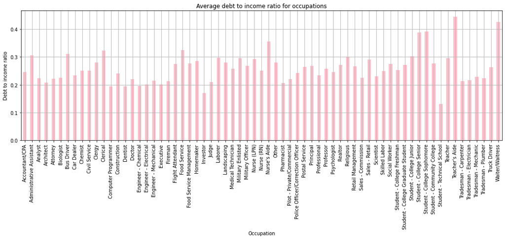

```python
plotThisbar(occupationsmean['DebtToIncomeRatio'],'Average debt to income ratio for occupations','Debt to income ratio','pink')
```

Let's check the average borrowers ARP among diffrent occupations.

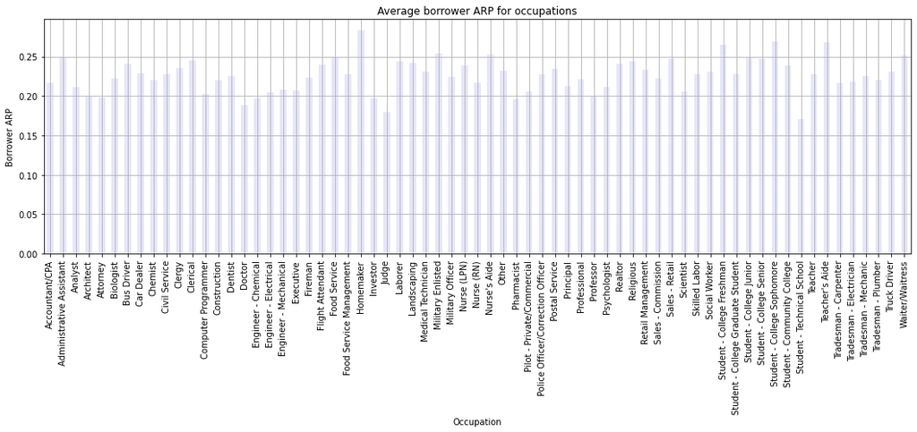

```python
plotThisbar(occupationsmean['BorrowerAPR'],'Average borrower ARP for occupations','Borrower ARP','lavender')
```

Most borrowers have ARP between 20% and 25%. Homemakers have the highest average ARP among occupations. Teacher's Aides have very high average ARP and Students in Technical schools lowest. We may expect that Income to Debt Ratio has some influence on borrowers ARP since most of the occupations with higher debt to income ratio has higher ARP as well.

What was the average Prosper Score for each occupation?

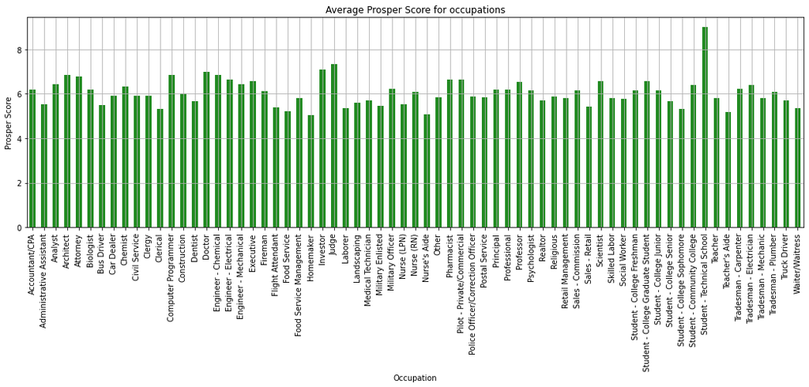

```python
plotThisbar(occupationsmean['ProsperScore'],'Average Prosper Score for occupations','Prosper Score','forestgreen')
```

And here We got opposite. Occupations that previously had lower ARP has a higher Prosper Score.

Was the term of a loan influential towards it's ARP?

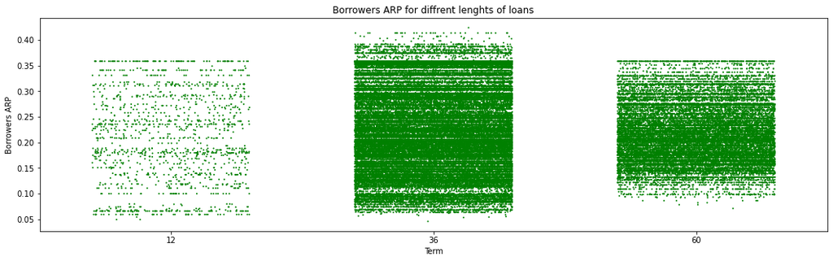

```python
plt.figure(figsize=[18,5])
sb.stripplot(data=loans,x='Term',y='BorrowerAPR',color='green',size=2,jitter=0.3)
plt.title('Borrowers ARP for diffrent lenghts of loans')
plt.ylabel('Borrowers ARP')
plt.xlabel('Term');
```

The most popular term for loans is 36 months, and that's a term with most variates of ARP.

Do people with better Prosper Score gets better ARP's?

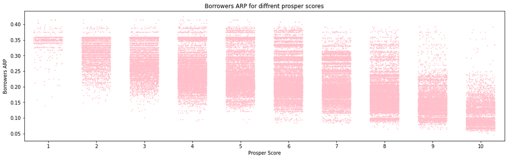

```python
plt.figure(figsize=[18,5])
sb.stripplot(data=loans,x='ProsperScore',y='BorrowerAPR',color='pink',size=2,jitter=0.3)
plt.title('Borrowers ARP for diffrent prosper scores')
plt.ylabel('Borrowers ARP')
plt.xlabel('Prosper Score');
```

This one is very clear: better Prosper Score We have better ARP We are getting.

Let's check if Debt To Income Ratio affecting our Prosper Score.

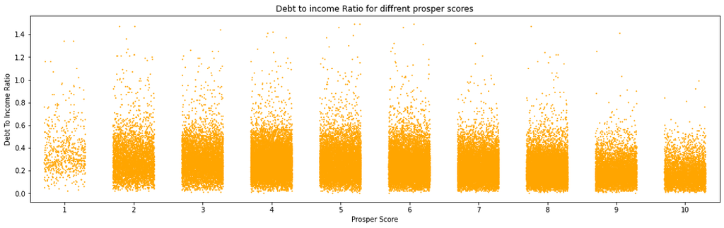

```python
loans['Debt35'] = loans['DebtToIncomeRatio'].where(loans['DebtToIncomeRatio']<1.5)
plt.figure(figsize=[18,5])
sb.stripplot(data=loans,x='ProsperScore',y='Debt35',color='orange',size=2,jitter=0.3)
plt.title('Debt to income Ratio for diffrent prosper scores')
plt.ylabel('Debt To Income Ratio')
plt.xlabel('Prosper Score');
```

Borrowers with higher prosper score tends to have lower Debt To Income Ratio.

Was the Borrower Rate actual ARP?

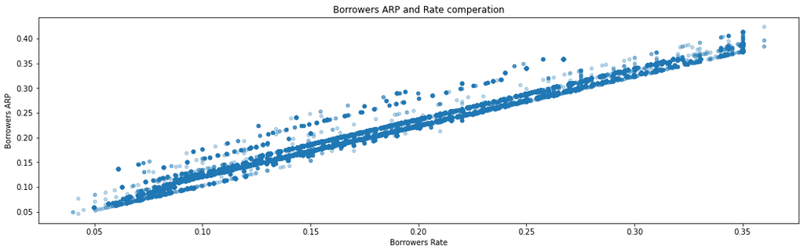

```python
loans.plot(kind='scatter',x='BorrowerRate',y='BorrowerAPR',figsize=(18,5),legend=False,ylabel='Borrowers ARP',
           xlabel='Borrowers Rate', title="Borrowers ARP and Rate comperation",alpha=0.3);
```

As We can see, ARP can be higher than a Rate up to 5%. While signing a loan agreement We should look at other cost which could affect our ARP such as commissions, insurances etc.

# Multivariate Exploration

What Was the borrowers ARP for diffrent prosper scores and loan terms?

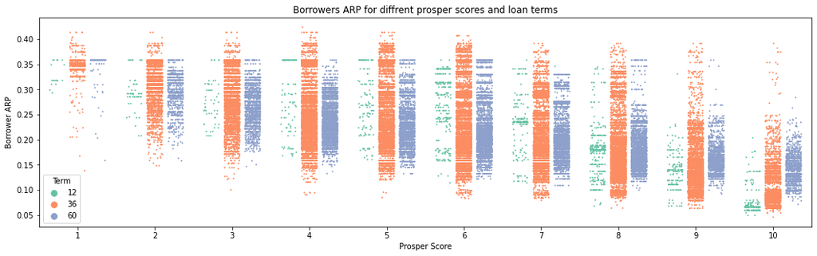

```python
plt.figure(figsize=[18,5])
sb.stripplot(data=loans,x='ProsperScore',y='BorrowerAPR',hue='Term',dodge=True,palette="Set2",size=2,jitter=0.3)
plt.title('Borrowers ARP for diffrent prosper scores and loan terms')
plt.ylabel('Borrower ARP')
plt.xlabel('Prosper Score');
```

The most common loan term is 36 months, and this one has a variety of ARP's. 12 months loans tends to be cheaper for a higher prosper score.

What Was the borrowers ARP for diffrent prosper scores in relation to owning a property?

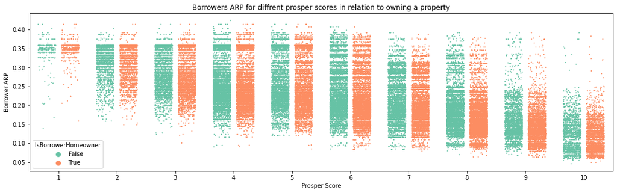

```python
plt.figure(figsize=[18,5])
sb.stripplot(data=loans,x='ProsperScore',y='BorrowerAPR',hue='IsBorrowerHomeowner',dodge=True,palette="Set2",size=2,jitter=0.3)
plt.title('Borrowers ARP for diffrent prosper scores in relation to owning a property')
plt.ylabel('Borrower ARP')
plt.xlabel('Prosper Score');
```

Having a property seems to have no effect on borrowers ARP, no matter what prosper score the borrower has.

# Conclusions

What affect Borrowers ARP the most is Prosper Score. Different occupations get different Prosper Scores of average. Owning a property does not affect our loan ARP or Prosper Score much. Term of loan sometimes could have effect on loan. Peoples with high Prosper Scores got lower Debt to Income Ratio on average.